# l7_quant2_ii_en

## Bars: counting, calculating percentages, and comparing groups

- Graph A: counting
- Graph B: percentages
- Graph C: position = “fill”
- Graph D: dodge
- Graph E: weighting

`geom_bar()` **counts** on its own how many rows there are in each category. It only needs one variable.

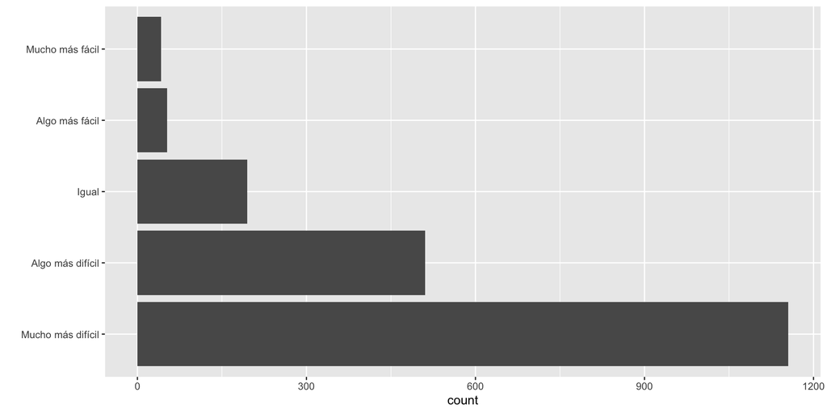

```r
d %>%
  filter(!is.na(acceso_vivienda)) %>%
  ggplot(aes(y = acceso_vivienda)) +
  geom_bar()
```

If we’ve already calculated the value, we use `geom_col()`: the height is whatever is in `x` (or `y`).

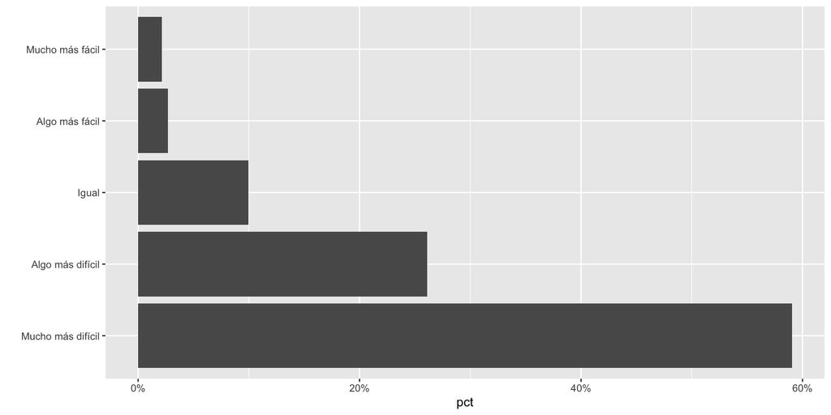

```r
d %>%
  filter(!is.na(acceso_vivienda)) %>%
  count(acceso_vivienda) %>%
  mutate(pct = n / sum(n)) %>%
  ggplot(aes(x = pct, y = acceso_vivienda)) +
  geom_col() +
  scale_x_continuous(labels = percent)
```

To compare **proportions** between groups, each bar adds up to 100%.

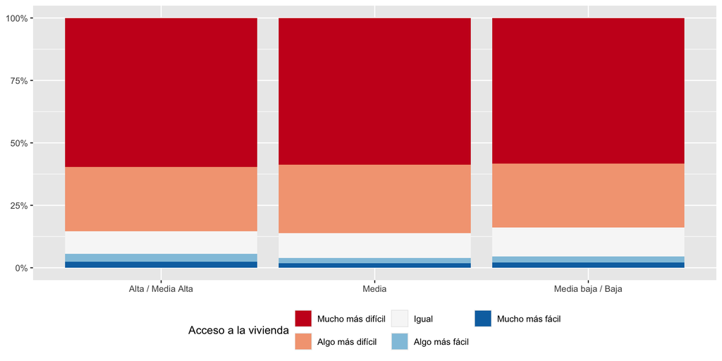

```r
d %>%
  filter(!is.na(acceso_vivienda)) %>%
  ggplot(aes(x = clase_social, fill = acceso_vivienda)) +
  geom_bar(position = "fill") +
  scale_y_continuous(labels = percent) +
  scale_fill_brewer(palette = "RdBu") +
  labs(x = NULL, y = NULL, fill = "Acceso a la vivienda") +
  theme(legend.position = "bottom") +
  guides(fill = guide_legend(nrow = 2))
```

`position = "dodge"` places bars **side by side**. You see the cases, not the proportions.

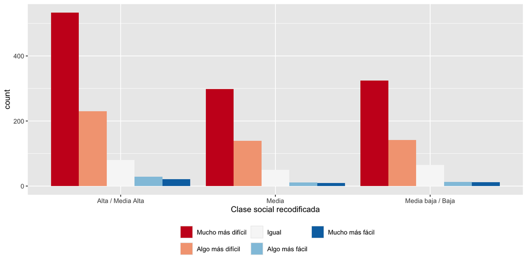

```r
d %>%
  filter(!is.na(acceso_vivienda)) %>%
  ggplot(aes(x = clase_social, fill = acceso_vivienda)) +
  geom_bar(position = "dodge") +
  scale_fill_brewer(palette = "RdBu") +
  theme(legend.position = "bottom") +
  guides(fill = guide_legend(nrow = 2))
```

The sample was corrected using the `ponde` variable. In `geom_bar()` we use the `weight` aesthetic. Each person counts “more” or “less” than 1.

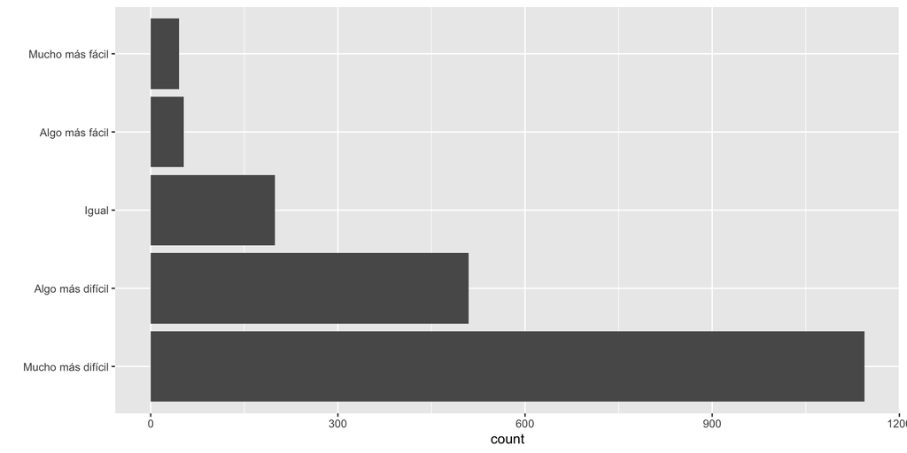

```r
d %>%
  filter(!is.na(acceso_vivienda)) %>%
  ggplot(aes(y = acceso_vivienda)) +
  geom_bar(aes(weight = ponde))
```

Compare with Graph A. The `count` axis is no longer people, but the **sum of weights**.